# Developmental Analysis of New York State Budget Capital Appropriations

### Economic Inequality in Public Spending (programme based)

Observation of the budget appropriations for gov't agencies gives a general idea on gov't policy. However, the actual use of the appropriations within agencies may not directly be applied to intitiaves or programmes that directly identify with public character or identity of the agencies. An example, say, a department of environmental conservation, where appropriatons is directed towards general maintenance of tools/facilities, or upgrades for information technology services.

Will now draw attention to programmes or operations among the agencies.

**Gini Index**

```python
# Aggregate appropriations per agency or program for each year
agg_year = df_times.groupby(["fiscal_period", "state_purpose"])["appropriations"].sum().reset_index()

# Compute Gini per fiscal period
gini_by_year = agg_year.groupby("fiscal_period")["appropriations"].apply(lambda x: gini(x.values))

print(gini_by_year)
```

```
fiscal_period
2015-16    0.758984
2016-17    0.784890
2017-18    0.738950
2018-19    0.743850
2019-20    0.765380
2020-21    0.720226
2021-22    0.758898
2023-24    0.714401
2024-25    0.758070
2025-26    0.693056
Name: appropriations, dtype: float64
```

## Executive Request Budget Appropriations

In the context of the New York State budget, the distinction between the Executive Budget and the Enacted Budget is primarily one of "proposal vs. law.

**Capital Appropriations: Executive vs. Enacted**

Capital appropriations are unique because they often span multiple years. In the transition from Executive to Enacted, three things typically happen:

Project "Adds": The Legislature (Senate and Assembly) often adds specific local capital projects (like community center renovations or specific local park upgrades) that were not in the Governor's original list.

Legislative Vetoes/Cuts: While rare for essential infrastructure, the Legislature may reject certain policy-driven capital funds if they disagree with the implementation language (e.g., specific housing mandates tied to infrastructure funds).

Article VII Language: The Governor’s "Executive" budget includes "Article VII" bills—legislative language that dictates how capital money is spent. The "Enacted" version often modifies this language to give the Legislature more oversight or to change eligibility criteria for grants.

| Feature | Executive Budget (Proposal) | Enacted Budget (Law) |
| --- | --- | --- |
| Origin & Timeline | BEGINS: JANUARY Submitted by the Governor to the Legislature. | BEGINS: APRIL 1 Negotiated and passed by both Houses. |
| Legal Status | A policy roadmap and spending request. | Legal authorization to obligate state funds. |
| Capital Logic | Focuses on the Governor’s long-term agency plans (DOT, Parks). | Includes legislative "adds" for specific local infrastructure. |
| Modifications | Updated via 30-day amendments by the Governor. | Requires supplemental bills or future-year reappropriations. |
| Common Name | The "Yellow" or "White" Book Analysis. | The "Green Book" (Report of Fiscal Committees). |

## NYS Executive Budget: Capital Appropriations Dictionary

| Column Name | API Field Name | Data Type | Description |
| --- | --- | --- | --- |
| Agency Name | agency_name | Text | The state department or authority responsible for the appropriation (e.g., DOT, OGS). |
| Reference Number | reference_number | Text | The unique identifier for the specific capital project "trip." Crucial for multi-year tracking. |
| Program Name | program_name | Text | The overarching initiative or category the project falls under. |
| State Purpose | state_purpose | Text | Code representing the specific legislative intent or goal of the funding. |
| Fund Name | fund_name | Text | The accounting fund from which spending is authorized (e.g., Capital Projects Fund). |
| Financing Source | financing_source | Text | How the trip is paid for: State bonds, federal aid, or hard cash (General Fund). |
| Chapter/Section/Year | chapter_section_year | Text | Legal citation referencing the original legislative act that authorized the project. |
| Description | description | Text | Brief narrative outlining the scope of work for the independent project. |
| Reappropriations Recommended | reappropriations_recommended | Number | Unspent funds from previous years requested to be carried forward into the new cycle. |
| Encumbrances | encumbrance_as_of_... | Number | Funds already legally committed to contracts/vendors at the time of the budget snapshot. |
| Appropriations Recommended | appropriations_recommended | Number | New spending authority requested by the Governor for the upcoming fiscal year. |

## Data Assimilation and Data Wrangling for Executive Budget Proposal Data

Routine to determine in matching data sets:

```python
# Define the datasets with their IDs
datasets = {
    "2015-16": "d7vq-82jt",
    "2016-17": "in6g-eta3",
    "2017-18": "4ukq-mtyf",
    "2018-19": "atzh-qh32",
    "2019-20": "ut2e-pvb7",
    "2020-21": "w3xg-gkfi",
    "2021-22": "m2md-ig66",
    "2023-24": "5mbb-q4ki",
    "2024-25": "ckc5-wk92",
    "2025-26": "ppyw-7cnd",
}

# Try different domains that might host these datasets
domains = [
    "data.ny.gov",
    "data.cityofnewyork.us",
    "health.data.ny.gov",
    "opendata.cityofnewyork.us"
]

# Your app token
app_token = "JIIHuvE7mmTf675a8ZoGCMD5R"

# Dictionary to store metadata
dataset_metadata = {}

# Function to normalize titles by removing year patterns
def normalize_title(title):
    # Remove year patterns like "2013-14", "2013-2014", "2013/14", etc.
    normalized = re.sub(r'\b(19|20)\d{2}[-/](\d{2}|\d{4})\b', 'YEAR', title)
    # Remove fiscal year references
    normalized = re.sub(r'\bFY\s*\d{2,4}[-/]?\d{0,4}\b', 'FISCAL_YEAR', normalized, flags=re.IGNORECASE)
    # Remove standalone years
    normalized = re.sub(r'\b(19|20)\d{2}\b', 'YEAR', normalized)
    return normalized.strip()

# Retrieve metadata for each dataset
print("Retrieving metadata for all datasets...")
for year, dataset_id in datasets.items():
    for domain in domains:
        try:
            client = Socrata(domain, app_token)
            metadata = client.get_metadata(dataset_id)

            if metadata:
                title = metadata.get('name', '')
                description = metadata.get('description', '')
                column_count = len(metadata.get('columns', []))

                dataset_metadata[year] = {
                    'domain': domain,
                    'id': dataset_id,
                    'title': title,
                    'normalized_title': normalize_title(title),
                    'description': description,
                    'column_count': column_count
                }

                print(f"✓ Found {year} dataset: \"{title}\" on {domain}")
                break

        except Exception as e:
            pass

    if year not in dataset_metadata:
        print(f"✗ Could not find metadata for {year} dataset (ID: {dataset_id})")

# Analyze title consistency
if dataset_metadata:
    print("\n--- TITLE ANALYSIS ---")

    # Group by normalized titles
    title_groups = defaultdict(list)
    for year, data in dataset_metadata.items():
        title_groups[data['normalized_title']].append(year)

    # Check if all titles are equivalent (after normalization)
    if len(title_groups) == 1:
        print("✓ All dataset titles are equivalent after normalizing year references.")
        print(f"Normalized title pattern: \"{list(title_groups.keys())[0]}\"")
    else:
        print(f"✗ Found {len(title_groups)} different title patterns:")
        for i, (normalized_title, years) in enumerate(title_groups.items(), 1):
            years_str = ", ".join(years)
            print(f"  Pattern {i}: \"{normalized_title}\"")
            print(f"    Used in years: {years_str}")

    # Compare original titles
    print("\n--- ORIGINAL TITLES ---")
    for year, data in sorted(dataset_metadata.items()):
        print(f"{year}: \"{data['title']}\"")

    # Compare column counts
    print("\n--- COLUMN COUNT COMPARISON ---")
    column_counts = {year: data['column_count'] for year, data in dataset_metadata.items()}
    if len(set(column_counts.values())) == 1:
        print(f"✓ All datasets have the same number of columns: {next(iter(column_counts.values()))}")
    else:
        print("✗ Datasets have different numbers of columns:")
        for year, count in sorted(column_counts.items()):
            print(f"  {year}: {count} columns")

    # Find the most similar titles using difflib
    print("\n--- SIMILARITY ANALYSIS ---")
    titles = [(year, data['title']) for year, data in dataset_metadata.items()]

    if len(titles) > 1:
        print("Title similarity scores (higher = more similar):")
        for i, (year1, title1) in enumerate(titles):
            for year2, title2 in titles[i+1:]:
                similarity = difflib.SequenceMatcher(None, title1, title2).ratio()
                print(f"  {year1} vs {year2}: {similarity:.2f}")

    # Suggest a common title pattern
    if dataset_metadata:
        print("\n--- SUGGESTED COMMON TITLE ---")
        # Extract the most common words across all titles
        all_titles = [data['title'] for data in dataset_metadata.values()]
        common_words = set(all_titles[0].lower().split())
        for title in all_titles[1:]:
            common_words &= set(title.lower().split())

        if common_words:
            print(f"Common words across all titles: {', '.join(common_words)}")
        else:
            print("No common words found across all titles.")
else:
    print("No metadata could be retrieved for any dataset.")
```

```
Retrieving metadata for all datasets...
✓ Found 2015-16 dataset: "New York State Executive Budget Capital Appropriations: 2015-2016" on data.ny.gov
✓ Found 2016-17 dataset: "New York State Executive Budget Capital Appropriations: 2016-2017" on data.ny.gov
✓ Found 2017-18 dataset: "New York State Executive Budget Capital Appropriations: 2017-2018" on data.ny.gov
✓ Found 2018-19 dataset: "New York State Executive Budget Capital Appropriations: 2018-2019" on data.ny.gov
✓ Found 2019-20 dataset: "New York State Executive Budget Capital Appropriations: 2019-2020" on data.ny.gov
✓ Found 2020-21 dataset: "New York State Executive Budget Capital Appropriations: 2020-21" on data.ny.gov
✓ Found 2021-22 dataset: "New York State Executive Budget Capital Appropriations: 2021-22" on data.ny.gov
✓ Found 2023-24 dataset: "New York State Executive Budget Capital Appropriations: 2023-24" on data.ny.gov
✓ Found 2024-25 dataset: "New York State Executive Budget Capital Appropriations: 2024-25" on data.ny.gov
✓ Found 2025-26 dataset: "New York State Executive Budget Capital Appropriations: 2025-26" on data.ny.gov

--- TITLE ANALYSIS ---
✓ All dataset titles are equivalent after normalizing year references.
Normalized title pattern: "New York State Executive Budget Capital Appropriations: YEAR"

--- ORIGINAL TITLES ---
2015-16: "New York State Executive Budget Capital Appropriations: 2015-2016"
2016-17: "New York State Executive Budget Capital Appropriations: 2016-2017"
2017-18: "New York State Executive Budget Capital Appropriations: 2017-2018"
2018-19: "New York State Executive Budget Capital Appropriations: 2018-2019"
2019-20: "New York State Executive Budget Capital Appropriations: 2019-2020"
2020-21: "New York State Executive Budget Capital Appropriations: 2020-21"
2021-22: "New York State Executive Budget Capital Appropriations: 2021-22"
2023-24: "New York State Executive Budget Capital Appropriations: 2023-24"
2024-25: "New York State Executive Budget Capital Appropriations: 2024-25"
2025-26: "New York State Executive Budget Capital Appropriations: 2025-26"

--- COLUMN COUNT COMPARISON ---
✓ All datasets have the same number of columns: 11

--- SIMILARITY ANALYSIS ---
Title similarity scores (higher = more similar):
  2015-16 vs 2016-17: 0.97
  2015-16 vs 2017-18: 0.97
  2015-16 vs 2018-19: 0.97
  2015-16 vs 2019-20: 0.95
  2015-16 vs 2020-21: 0.95
  2015-16 vs 2021-22: 0.95
  2015-16 vs 2023-24: 0.94
```

[output cut: 26 more lines]

```
  2019-20 vs 2024-25: 0.94
  2019-20 vs 2025-26: 0.94
  2020-21 vs 2021-22: 0.97
  2020-21 vs 2023-24: 0.97
  2020-21 vs 2024-25: 0.97
  2020-21 vs 2025-26: 0.97
  2021-22 vs 2023-24: 0.97
  2021-22 vs 2024-25: 0.97
  2021-22 vs 2025-26: 0.97
  2023-24 vs 2024-25: 0.97
  2023-24 vs 2025-26: 0.97
  2024-25 vs 2025-26: 0.97

--- SUGGESTED COMMON TITLE ---
Common words across all titles: capital, york, appropriations:, executive, new, state, budget
```

To now officially assimilate the numerous data sets, and observing the properties of each before aggregating into a single dataframe.

```python
client = Socrata("data.ny.gov", "JIIHuvE7mmTf675a8ZoGCMD5R")  # Data source website and application token

datasets = {
    "2015-16": "d7vq-82jt",
    "2016-17": "in6g-eta3",
    "2017-18": "4ukq-mtyf",
    "2018-19": "atzh-qh32",
    "2019-20": "ut2e-pvb7",
    "2020-21": "w3xg-gkfi",
    "2021-22": "m2md-ig66",
    "2023-24": "5mbb-q4ki",
    "2024-25": "ckc5-wk92",
    "2025-26": "ppyw-7cnd",
} # assimilation of data for different successive periods

exec_dfs = {} # dictionary

for period, ds_id in datasets.items():

    # ---- 1) fast server-side row count ----
    count_query = client.get(ds_id, select="count(*) as n")
    n_rows = int(count_query[0]["n"])

    print(f"\n===== {period} =====")
    print(f"Rows (server count): {n_rows}")

    # ---- 2) download full dataset ----
    results = client.get(ds_id, limit=n_rows)
    df = pd.DataFrame(results)

    # ---- 3) add period column immediately ----
    df["fiscal_period"] = period

    # ---- 4) inspect structure ----
    df.info()

    exec_dfs[period] = df
```

```
===== 2015-16 =====
Rows (server count): 2135
<class 'pandas.core.frame.DataFrame'>
RangeIndex: 2135 entries, 0 to 2134
Data columns (total 12 columns):
 #   Column                                Non-Null Count  Dtype
---  ------                                --------------  -----
 0   agency_name                           2135 non-null   object
 1   reference_number                      2135 non-null   object
 2   program_name                          2135 non-null   object
 3   state_purpose                         2135 non-null   object
 4   fund_name                             2135 non-null   object
 5   financing_source                      2135 non-null   object
 6   chapter_section_year                  2135 non-null   object
 7   description                           2135 non-null   object
 8   reappropriations_recommended_2015_16  2135 non-null   object
 9   encumbrance_as_of_01_15_2015          2135 non-null   object
 10  appropriations_recommended_2015_16    2135 non-null   object
 11  fiscal_period                         2135 non-null   object
dtypes: object(12)
memory usage: 200.3+ KB

===== 2016-17 =====
Rows (server count): 2316
<class 'pandas.core.frame.DataFrame'>
RangeIndex: 2316 entries, 0 to 2315
Data columns (total 12 columns):
 #   Column                                Non-Null Count  Dtype
---  ------                                --------------  -----
 0   agency_name                           2316 non-null   object
 1   reference_number                      2316 non-null   object
 2   program_name                          2316 non-null   object
 3   state_purpose                         2316 non-null   object
 4   fund_name                             2316 non-null   object
 5   financing_source                      2316 non-null   object
 6   chapter_section_year                  2316 non-null   object
 7   description                           2316 non-null   object
 8   reappropriations_recommended_2016_17  2316 non-null   object
 9   encumbrance_as_of_1_11_2016           2316 non-null   object
 10  appropriations_recommended_2016_17    2316 non-null   object
```

[output cut: 164 more lines]

```
---  ------                        --------------  -----
 0   agency_name                   3635 non-null   object
 1   reference_number              3635 non-null   object
 2   program_name                  3635 non-null   object
 3   state_purpose                 3635 non-null   object
 4   fund_name                     3635 non-null   object
 5   financing_source              3635 non-null   object
 6   chapter_section_year          3635 non-null   object
 7   description                   3635 non-null   object
 8   reappropriations_recommended  3635 non-null   object
 9   encumbrance_as_of_1_17_2025   3635 non-null   object
 10  appropriations_recommended    3635 non-null   object
 11  fiscal_period                 3635 non-null   object
dtypes: object(12)
memory usage: 340.9+ KB
```

To now aggregate all the data sets and to resolve the naming inconsistencies. In addition, to also identify possible data mismatches/inconsistencies between the individual data sets and the aggregated dataset.

```python
from sodapy import Socrata
import pandas as pd

# -----------------------------
# 1) Normalize columns function
# -----------------------------
def normalize_budget_columns(df, fiscal_period):
    """
    Standardizes NY budget columns into 12 consistent columns.
    """
    standard_columns = [
        'agency_name', 'reference_number', 'program_name', 'state_purpose',
        'fund_name', 'financing_source', 'chapter_section_year', 'description',
        'reappropriations_recommended', 'encumbrances', 'appropriations_recommended', 'fiscal_period'
    ]

    new_names = {}
    for col in df.columns:
        col_lower = col.lower()
        if 'reappropriations' in col_lower:
            new_names[col] = 'reappropriations'
        elif 'appropriations' in col_lower:
            new_names[col] = 'appropriations'
        elif 'encumbrance' in col_lower:
            new_names[col] = 'encumbrances'

    df = df.rename(columns=new_names)
    df['fiscal_period'] = fiscal_period

    # Ensure all standard columns exist
    for col in standard_columns:
        if col not in df.columns:
            df[col] = None
    return df[standard_columns]

# -----------------------------
# 2) Download, normalize, and concatenate datasets
# -----------------------------
client = Socrata("data.ny.gov", "JIIHuvE7mmTf675a8ZoGCMD5R")

datasets = {
    "2015-16": "d7vq-82jt",
    "2016-17": "in6g-eta3",
    "2017-18": "4ukq-mtyf",
    "2018-19": "atzh-qh32",
    "2019-20": "ut2e-pvb7",
    "2020-21": "w3xg-gkfi",
    "2021-22": "m2md-ig66",
    "2023-24": "5mbb-q4ki",
    "2024-25": "ckc5-wk92",
    "2025-26": "ppyw-7cnd",
} # assimilation of data for different successive periods

exec_dfs = {}

for period, ds_id in datasets.items():
    count_query = client.get(ds_id, select="count(*) as n")
    n_rows = int(count_query[0]["n"])
    print(f"\n===== {period} ===== Rows: {n_rows}")

    results = client.get(ds_id, limit=n_rows)
    df = pd.DataFrame(results)
    df_norm = normalize_budget_columns(df, period)

    exec_dfs[period] = df_norm

exec_final_df = pd.concat(exec_dfs.values(), ignore_index=True)

# -----------------------------
# 3) Full validation pipeline
# -----------------------------
mismatch_records = []

for period, df_orig in exec_dfs.items():
    for idx, row_orig in df_orig.iterrows():
        # Normalize row
        row_norm = normalize_budget_columns(df_orig.iloc[[idx]], period).iloc[0]

        # Find matching row in final_df by unique key
        matched_rows = exec_final_df[
            (exec_final_df['fiscal_period'] == row_norm['fiscal_period']) &
            (exec_final_df['agency_name'] == row_norm['agency_name']) &
            (exec_final_df['reference_number'] == row_norm['reference_number'])
        ]

        if matched_rows.empty:
            # Record missing row in final_df
            mismatch_records.append({
                'fiscal_period': row_norm['fiscal_period'],
                'agency_name': row_norm['agency_name'],
                'reference_number': row_norm['reference_number'],
                'mismatch_type': 'Missing in final_df'
            })
            continue

        row_agg = matched_rows.iloc[0]

        # Compare all columns
        for col in row_norm.index:
            val_orig = str(row_norm[col])
            val_agg = str(row_agg[col])
            if val_orig != val_agg:
                mismatch_records.append({
                    'fiscal_period': row_norm['fiscal_period'],
                    'agency_name': row_norm['agency_name'],
                    'reference_number': row_norm['reference_number'],
                    'column': col,
                    'original_value': val_orig,
                    'aggregated_value': val_agg
                })

# -----------------------------
# 4) Export mismatch summary
# -----------------------------
df_mismatches = pd.DataFrame(mismatch_records)
df_mismatches.to_csv("budget_mismatches_summary.csv", index=False)
print(f"Total mismatches found: {len(df_mismatches)}")
```

```
===== 2015-16 ===== Rows: 2135

===== 2016-17 ===== Rows: 2316

===== 2017-18 ===== Rows: 2426

===== 2018-19 ===== Rows: 2567

===== 2019-20 ===== Rows: 2691

===== 2020-21 ===== Rows: 2838

===== 2021-22 ===== Rows: 2959

===== 2023-24 ===== Rows: 3303

===== 2024-25 ===== Rows: 3480

===== 2025-26 ===== Rows: 3635
Total mismatches found: 0
```

```python
from sodapy import Socrata
import pandas as pd

# -----------------------------
# 1) Normalize columns function
# -----------------------------
def normalize_budget_columns(df, fiscal_period):

    df = df.copy()   # <-- ADD THIS LINE
    df.columns = df.columns.str.lower()

    standard_columns = [
        'agency_name',
        'reference_number',
        'program_name',
        'state_purpose',
        'fund_name',
        'financing_source',
        'chapter_section_year',
        'description',
        'reappropriations_recommended',
        'encumbrances',
        'appropriations_recommended',
        'fiscal_period'
    ]

    # Identify column groups
    reapp_cols = [c for c in df.columns if 'reappropriation' in c]
    appr_cols = [c for c in df.columns if 'appropriation' in c and 'reappropriation' not in c]
    encum_cols = [c for c in df.columns if 'encumbrance' in c]

    # Merge columns safely
    if reapp_cols:
        df.loc[:, 'reappropriations_recommended'] = df[reapp_cols].bfill(axis=1).iloc[:, 0]
    else:
        df.loc[:, 'reappropriations_recommended'] = None

    if appr_cols:
        df.loc[:, 'appropriations_recommended'] = df[appr_cols].bfill(axis=1).iloc[:, 0]
    else:
        df.loc[:, 'appropriations_recommended'] = None

    if encum_cols:
        df.loc[:, 'encumbrances'] = df[encum_cols].bfill(axis=1).iloc[:, 0]
    else:
        df.loc[:, 'encumbrances'] = None

    df.loc[:, 'fiscal_period'] = fiscal_period

    # Ensure all columns exist
    for col in standard_columns:
        if col not in df.columns:
            df[col] = None

    return df[standard_columns]


# -----------------------------
# 2) Download datasets
# -----------------------------
client = Socrata("data.ny.gov", "JIIHuvE7mmTf675a8ZoGCMD5R")

datasets = {
    "2015-16": "d7vq-82jt",
    "2016-17": "in6g-eta3",
    "2017-18": "4ukq-mtyf",
    "2018-19": "atzh-qh32",
    "2019-20": "ut2e-pvb7",
    "2020-21": "w3xg-gkfi",
    "2021-22": "m2md-ig66",
    "2023-24": "5mbb-q4ki",
    "2024-25": "ckc5-wk92",
    "2025-26": "ppyw-7cnd"
}

exec_dfs = {}

for period, ds_id in datasets.items():

    count_query = client.get(ds_id, select="count(*) as n")
    n_rows = int(count_query[0]["n"])

    print(f"\n===== {period} ===== Rows: {n_rows}")

    results = client.get(ds_id, limit=n_rows)
    df = pd.DataFrame(results)

    df_norm = normalize_budget_columns(df, period)

    exec_dfs[period] = df_norm


# -----------------------------
# 3) Concatenate all datasets
# -----------------------------
exec_final_df = pd.concat(exec_dfs.values(), ignore_index=True)

print("\nFinal dataset shape:", exec_final_df.shape)

# Optional inspection
print(exec_final_df.info())


# -----------------------------
# 4) Full validation pipeline
# -----------------------------
mismatch_records = []

for period, df_orig in exec_dfs.items():

    for idx, row_orig in df_orig.iterrows():

        row_norm = normalize_budget_columns(
            df_orig.iloc[[idx]],
            period
        ).iloc[0]

        matched_rows = exec_final_df[
            (exec_final_df['fiscal_period'] == row_norm['fiscal_period']) &
            (exec_final_df['agency_name'] == row_norm['agency_name']) &
            (exec_final_df['reference_number'] == row_norm['reference_number'])
        ]

        if matched_rows.empty:

            mismatch_records.append({
                'fiscal_period': row_norm['fiscal_period'],
                'agency_name': row_norm['agency_name'],
                'reference_number': row_norm['reference_number'],
                'mismatch_type': 'Missing in final_df'
            })

            continue

        row_agg = matched_rows.iloc[0]

        for col in row_norm.index:

            val_orig = str(row_norm[col])
            val_agg = str(row_agg[col])

            if val_orig != val_agg:

                mismatch_records.append({
                    'fiscal_period': row_norm['fiscal_period'],
                    'agency_name': row_norm['agency_name'],
                    'reference_number': row_norm['reference_number'],
                    'column': col,
                    'original_value': val_orig,
                    'aggregated_value': val_agg
                })


# -----------------------------
# 5) Export mismatch summary
# -----------------------------
df_mismatches = pd.DataFrame(mismatch_records)

df_mismatches.to_csv(
    "budget_mismatches_summary.csv",
    index=False
)

print("\nTotal mismatches found:", len(df_mismatches))
```

```
===== 2015-16 ===== Rows: 2135

===== 2016-17 ===== Rows: 2316

===== 2017-18 ===== Rows: 2426

===== 2018-19 ===== Rows: 2567

===== 2019-20 ===== Rows: 2691

===== 2020-21 ===== Rows: 2838

===== 2021-22 ===== Rows: 2959

===== 2023-24 ===== Rows: 3303

===== 2024-25 ===== Rows: 3480

===== 2025-26 ===== Rows: 3635

Final dataset shape: (28350, 12)
<class 'pandas.core.frame.DataFrame'>
RangeIndex: 28350 entries, 0 to 28349
Data columns (total 12 columns):
 #   Column                        Non-Null Count  Dtype
---  ------                        --------------  -----
 0   agency_name                   28350 non-null  object
 1   reference_number              28350 non-null  object
 2   program_name                  28350 non-null  object
 3   state_purpose                 28350 non-null  object
 4   fund_name                     28350 non-null  object
 5   financing_source              28350 non-null  object
 6   chapter_section_year          28350 non-null  object
 7   description                   28350 non-null  object
 8   reappropriations_recommended  28350 non-null  object
 9   encumbrances                  28350 non-null  object
 10  appropriations_recommended    28350 non-null  object
 11  fiscal_period                 28350 non-null  object
dtypes: object(12)
memory usage: 2.6+ MB
None

Total mismatches found: 0
```

Checking for consistency with data alignment, indexing, and value types remained consistent during the aggregation process:

```python
# Select the first row from one of the original dataframes (e.g., from 2013-14 dataset)
# Replace 'data_2005' with a dataset that exists in your dfs dictionary
row_original = exec_dfs["2015-16"].iloc[0]  # Using the first available dataset

row_agg = exec_final_df.iloc[0]

# Now your comparison code will work:
df_comp = pd.DataFrame({
    'Original_Values': row_original.sort_index().values,
    'Aggregated_Values': row_agg.sort_index().values
}, index=row_original.sort_index().index)

df_comp['Match'] = df_comp['Original_Values'].astype(str) == df_comp['Aggregated_Values'].astype(str)
print(df_comp)
```

```
                                                               Original_Values  \
agency_name                                             Adirondack Park Agency
appropriations_recommended                                                   0
chapter_section_year                                                0055/01/10
description                                        Miscellaneous Gifts Account
encumbrances                                                                 0
financing_source                                   Miscellaneous Gifts Account
fiscal_period                                                          2015-16
fund_name                                            Combined Expendable Trust
program_name                  Maintenance & Improvement of Existing Facilities
reappropriations_recommended                                            500000
reference_number                                                      13GI1003
state_purpose                                       Preservation of Facilities

                                                             Aggregated_Values  \
agency_name                                             Adirondack Park Agency
appropriations_recommended                                                   0
chapter_section_year                                                0055/01/10
description                                        Miscellaneous Gifts Account
encumbrances                                                                 0
financing_source                                   Miscellaneous Gifts Account
fiscal_period                                                          2015-16
fund_name                                            Combined Expendable Trust
program_name                  Maintenance & Improvement of Existing Facilities
reappropriations_recommended                                            500000
reference_number                                                      13GI1003
state_purpose                                       Preservation of Facilities

                              Match
agency_name                    True
appropriations_recommended     True
chapter_section_year           True
description                    True
encumbrances                   True
financing_source               True
fiscal_period                  True
fund_name                      True
program_name                   True
reappropriations_recommended   True
reference_number               True
state_purpose                  True
```

Validation check was a success! By comparing the first row of the source data (2015-16) against the combined dataset (final_df), confirmed is the data alignment, indexing, and value types remained consistent during the aggregation process.

Seeing "True" across the board is a great sign that the merge or concatenation logic didn't shift the data or introduce unintended nulls.

Checking for row integrity:

```python
def get_clean_hashes(df):
    # 1. Sort columns alphabetically so the order is identical for both
    df_sorted = df.reindex(sorted(df.columns), axis=1)

    # 2. Convert to string and hash
    # Using a list comprehension is faster than .apply(axis=1)
    return pd.Series([
        hashlib.md5("||".join(row).encode()).hexdigest()
        for row in df_sorted.astype(str).values
    ])

# Re-run the hashing on both
original_combined = pd.concat(exec_dfs.values(), ignore_index=True)

print("Hashing original data...")
original_hashes = get_clean_hashes(original_combined)

print("Hashing aggregated data...")
agg_hashes = get_clean_hashes(exec_final_df)

# Final Compare
assert original_hashes.value_counts().equals(agg_hashes.value_counts()), \
       "❌ Row-level mismatch still exists!"

print("✅ Row-level integrity verified!")
```

```
Hashing original data...
Hashing aggregated data...
✅ Row-level integrity verified!
```

From JSON based assimilation, transforming the financial attributes from object to numeric:

```python
num_cols = [
    'appropriations_recommended',
    'reappropriations_recommended',
    'encumbrances'
]

for c in num_cols:
    exec_final_df[c] = (
        exec_final_df[c]
        .astype(str)                        # ensure string
        .str.replace(',', '', regex=False)  # remove thousands separators
        .str.replace('$', '', regex=False)  # remove currency
        .str.strip()
        .replace({'': None, 'nan': None})
        .pipe(pd.to_numeric, errors='coerce')
    )

exec_final_df.info()
```

```
<class 'pandas.core.frame.DataFrame'>
RangeIndex: 28350 entries, 0 to 28349
Data columns (total 12 columns):
 #   Column                        Non-Null Count  Dtype
---  ------                        --------------  -----
 0   agency_name                   28350 non-null  object
 1   reference_number              28350 non-null  object
 2   program_name                  28350 non-null  object
 3   state_purpose                 28350 non-null  object
 4   fund_name                     28350 non-null  object
 5   financing_source              28350 non-null  object
 6   chapter_section_year          28350 non-null  object
 7   description                   28350 non-null  object
 8   reappropriations_recommended  28350 non-null  int64
 9   encumbrances                  28350 non-null  int64
 10  appropriations_recommended    28350 non-null  int64
 11  fiscal_period                 28350 non-null  object
dtypes: int64(3), object(9)
memory usage: 2.6+ MB
```

Orienting for fiscal operations, including multiyear executive (Governor) proposals:

```python
import pandas as pd

def get_nys_budget_dates(fy_str):
    """Calculates the proposal dates based on the fiscal period string (e.g., '2015-16')."""
    start_year = int(fy_str[:4])
    # The Executive Budget is proposed in Jan of the *previous* calendar year
    # Example: FY 2015-16 was proposed in Jan 2015.
    proposal_jan = pd.Timestamp(year=start_year, month=1, day=20)
    amendment_feb = pd.Timestamp(year=start_year, month=2, day=19)
    enacted_april = pd.Timestamp(year=start_year, month=4, day=1)
    return proposal_jan, amendment_feb, enacted_april

# Apply to your multi-year dataframe
exec_final_df = (
    exec_final_df.copy()
    .assign(
        # 1. Create the timestamp objects for each row's fiscal cycle
        dates = lambda x: x['fiscal_period'].apply(get_nys_budget_dates),
        proposal_date = lambda x: x['dates'].apply(lambda d: d[0]),
        amendment_date = lambda x: x['dates'].apply(lambda d: d[1]),
        enacted_date = lambda x: x['dates'].apply(lambda d: d[2]),

        # 2. Set the index to the Fiscal Year (e.g., 2016)
        fy = lambda x: pd.to_datetime(x['fiscal_period'].str[:4] + '-04-01').dt.to_period('Y-MAR'),

        # 3. Calculate "Days of Relevance"
        # How many days was this specific Governor proposal the active topic of debate?
        proposal_duration_days = lambda x: (x['enacted_date'] - x['proposal_date']).dt.days
    )
    .drop(columns=['dates'])
    .set_index('fy')
    .sort_index()
)
```

```python
exec_final_df.info()
```

```
<class 'pandas.core.frame.DataFrame'>
PeriodIndex: 28350 entries, 2016 to 2026
Freq: Y-MAR
Data columns (total 16 columns):
 #   Column                        Non-Null Count  Dtype
---  ------                        --------------  -----
 0   agency_name                   28350 non-null  object
 1   reference_number              28350 non-null  object
 2   program_name                  28350 non-null  object
 3   state_purpose                 28350 non-null  object
 4   fund_name                     28350 non-null  object
 5   financing_source              28350 non-null  object
 6   chapter_section_year          28350 non-null  object
 7   description                   28350 non-null  object
 8   reappropriations_recommended  28350 non-null  int64
 9   encumbrances                  28350 non-null  int64
 10  appropriations_recommended    28350 non-null  int64
 11  fiscal_period                 28350 non-null  object
 12  proposal_date                 28350 non-null  datetime64[ns]
 13  amendment_date                28350 non-null  datetime64[ns]
 14  enacted_date                  28350 non-null  datetime64[ns]
 15  proposal_duration_days        28350 non-null  int64
dtypes: datetime64[ns](3), int64(4), object(9)
memory usage: 3.7+ MB
```

## Measuring Legislative Intervention in Public Budgeting

The process through which a parliament or congress exercises its "power of the purse" to review, amend, approve, and oversee the government’s financial plans (Lienert, 2010). It is a cornerstone of democratic governance designed to ensure transparency, accountability, and the efficient use of public resources.

**Core Functions of Legislative Budget Intervention**

Legislative intervention occurs throughout the entire budget cycle, primarily through the following actions:

1. Approval and Amendments: The legislature reviews the executive's draft budget, with powers ranging from simply accepting it to, in some jurisdictions, significantly amending or reallocating funds.
2. Pre-Budget Scrutiny: Some legislatures engage in pre-budget debates (often in the middle of the year preceding the budget year) to set "hard" multi-year fiscal targets or spending ceilings that the government must follow.
3. Oversight and Monitoring: This involves reviewing in-year budget reports to ensure the executive is adhering to the approved budget.
4. Ex-post Auditing: After the fiscal year, the legislature (often through a Public Accounts Committee) reviews audit reports from the Supreme Audit Institution to hold the government accountable for expenditure.

### Legislative Additions Analysis

Measure projects added by the Legislature that were not in the Executive budget.

Notion:

$$Legislative\,Additions\,\,=\,\,Enacted\,\,-\,\,Executive$$

Types:

1. New projects/programmes (exist in enacted but not executive)
2. Funding increases (same project but larger appropriation)
3. Funding cuts

Merging on key fields/attributes:

agency_name, reference_number, and fiscal_period

To compute:

$$\Delta \text{appropriation} = \text{appropriations} - \text{appropriations\_recommended}$$

Key metrics:

1. number of added projects
2. dollar value added
3. percent of total budget altered

Research question:

How much of the capital budget is legislatively driven?

#### Aligning both Datasets - Executive vs Enacted Merge Pipeline

```python
# Merge
budget_compare = pd.merge(
    exec_final_df,
    df_times,
    on=["agency_name", "reference_number", "fiscal_period"],
    how="outer",
    suffixes=("_exec", "_enacted")
)

budget_compare.info()
```

```
<class 'pandas.core.frame.DataFrame'>
RangeIndex: 28986 entries, 0 to 28985
Data columns (total 25 columns):
 #   Column                        Non-Null Count  Dtype
---  ------                        --------------  -----
 0   agency_name                   28986 non-null  object
 1   reference_number              28986 non-null  object
 2   program_name_exec             28350 non-null  object
 3   state_purpose_exec            28350 non-null  object
 4   fund_name_exec                28350 non-null  object
 5   financing_source_exec         28350 non-null  object
 6   chapter_section_year_exec     28350 non-null  object
 7   description_exec              28350 non-null  object
 8   reappropriations_recommended  28350 non-null  float64
 9   encumbrances_exec             28350 non-null  float64
```

[output cut: 17 more lines]

**Diagosing the merge:**

Observed prior is seemingly a merger mess to be resolved. Adding an indicator column.

```python
budget_compare = pd.merge(
    exec_final_df,
    df_times,
    on=["agency_name","reference_number","fiscal_period"],
    how="outer",
    indicator=True,
    suffixes=("_exec","_enacted")
)
```

Observing the disparities (additions) and commonalities:

| merge type | meaning |
| --- | --- |
| both | matched rows |
| left_only | executive only |
| right_only | legislative only |

```python
budget_compare["_merge"].value_counts()
```

```
_merge
both          28219
right_only      636
left_only       131
Name: count, dtype: int64
```

Verify Row Preservation. Checking that original rows are preserved for proposed (executive) data.

```python
budget_compare["appropriations_recommended"].notna().sum()
```

```
np.int64(28350)
```

Verify Row Preservation. Checking that original rows are preserved for enacted (legislative) data.

```python
budget_compare["appropriations"].notna().sum()
```

```
np.int64(28855)
```

Identifying the extra rows (rows causing the increase):

```python
extra_rows = budget_compare[
    budget_compare["_merge"] != "both"
]

print(extra_rows)
```

```
                                             agency_name reference_number  \
473               Agriculture and Markets, Department of         60020607
474               Agriculture and Markets, Department of         60030607
475               Agriculture and Markets, Department of         60030607
476               Agriculture and Markets, Department of         60030607
492               Agriculture and Markets, Department of         60AS1707
...                                                  ...              ...
28935                         Victim Services, Office of         VSSF2103
28967                                 World Trade Center         17WT0220
28971                                 World Trade Center         2CWT0620
28972  World Trade Center - Department of Transportation         17WT0220
28979  World Trade Center - Department of Transportation         2CWT0620

        program_name_exec  state_purpose_exec            fund_name_exec  \
473                   NaN                 NaN                       NaN
```

[output cut: 90 more lines]

Detecting key duplication. Sometimes duplicates in merge keys cause row inflation.

```python
exec_final_df.duplicated(
    ["agency_name","reference_number","fiscal_period"]
).sum()
```

```
np.int64(0)
```

```python
exec_final_df.duplicated(
    ["agency_name","reference_number","fiscal_period"]
).sum()
```

```
np.int64(0)
```

```python
df_times.duplicated(
    ["agency_name","reference_number","fiscal_period"]
).sum()
```

```
np.int64(0)
```

Merge Validation:

```python
budget_compare_test = pd.merge(
    exec_final_df,
    df_times,
    on=["agency_name","reference_number","fiscal_period"],
    how="outer",
    validate="one_to_one"
)
```

If duplicates exist, pandas would have thrown an error.

Identify Legislative Additions Directly:

```python
legislative_projects = budget_compare[
    budget_compare["_merge"] == "right_only"
]

print(legislative_projects)
```

```
                                             agency_name reference_number  \
473               Agriculture and Markets, Department of         60020607
474               Agriculture and Markets, Department of         60030607
475               Agriculture and Markets, Department of         60030607
476               Agriculture and Markets, Department of         60030607
492               Agriculture and Markets, Department of         60AS1707
...                                                  ...              ...
28926                  Veterans’ Services, Department of         VEVC2203
28929                  Veterans’ Services, Department of         VEVC2303
28935                         Victim Services, Office of         VSSF2103
28972  World Trade Center - Department of Transportation         17WT0220
28979  World Trade Center - Department of Transportation         2CWT0620

      program_name_exec state_purpose_exec fund_name_exec  \
473                 NaN                NaN            NaN
```

[output cut: 90 more lines]

Identify Executive-only Proposals:

```python
executive_only = budget_compare[
    budget_compare["_merge"] == "left_only"
]

print(executive_only)
```

```
                                     agency_name reference_number  \
2930       Consolidated Capital Projects Program         73SC2009
3664      Criminal Justice Services, Division of         CJJS2508
5178        Empire State Development Corporation         91371709
7930   Environmental Conservation, Department of         09EP23ER
7931   Environmental Conservation, Department of         09EP24ER
...                                          ...              ...
28911            Veterans' Services, Division of         VENP2203
28912            Veterans' Services, Division of         VEVC2203
28913            Veterans' Services, Division of         VEVC2303
28967                         World Trade Center         17WT0220
28971                         World Trade Center         2CWT0620

                                       program_name_exec  \
2930                       Consolidated Capital Projects
```

[output cut: 116 more lines]

**Important Insight for Your Research:**

1. These unmatched rows are not errors.
2. They are exactly the political economy signal you want:

| Type | Interpretation |
| --- | --- |
| right_only | legislative pork-barrel additions |
| left_only | executive proposals rejected |

Pork barrel politics (Kenton, 2025) refers the legislative practice of slipping funding for a local project into a broader budget, even when said project may have little or nothing to do with the larger bill. Often, this funding may primarily benefit the legislator's home district, serving to garner or preserve political support among constituents. Pork barreling can have the effect of substantially inflating the cost of legislation.

**Immediate Research Statistics:**

Legistlative Addition Rate (percentage):

$$\frac{636}{28855}\times\,100\,\approx\,2.2\%$$

Executive Proposal Rejection Rate (percentage):

$$\frac{131}{28350}\times\,100\,\approx\,0.46\%$$

Hence, the Legislature mostly adds projects rather than removing them.

**Measuring the Financial Magnitude of Legislative Changes:**

This will convey:

1. how much money Legislature added
2. how much was cut
3. total budget change

```python
# Calculate the change column
budget_compare["change"] = (
    budget_compare["appropriations"] -
    budget_compare["appropriations_recommended"]
)

# If you want to maintain current behavior:
budget_compare.groupby("_merge", observed=False)["change"].sum()

# Or if you want to adopt the future default behavior:
# budget_compare.groupby("_merge", observed=True)["change"].sum()
```

```
_merge
left_only             0.0
right_only            0.0
both         -857340000.0
Name: change, dtype: float64
```

**Legislative Pork Concentration:**

Which agencies receive most legislative adds?

```python
legislative_adds = budget_compare[
    budget_compare["_merge"] == "right_only"
]

legislative_adds.groupby("agency_name")["appropriations"].sum().sort_values(ascending=False)
```

```
agency_name
Environmental Conservation, Department of                               5.994302e+09
Metropolitan Transportation Authority                                   3.185000e+09
State and Municipal Facilities Program                                  2.015000e+09
Housing and Community Renewal, Division of                              1.879600e+09
Empire State Development Corporation                                    1.792900e+09
State University of New York                                            1.410000e+09
Community Resiliency, Economic Sustainability and Technology Program    1.155000e+09
Transportation, Department of                                           1.097613e+09
City University of New York                                             7.300000e+08
Education Department, State                                             1.870000e+08
Motor Vehicles, Department of                                           1.784600e+08
Higher Education Facilities Capital Matching Grants Program             1.100000e+08
Health, Department of                                                   1.025320e+08
Local Community Assistance Program                                      1.000000e+08
Lake Ontario Resiliency/Economic Development                            1.000000e+08
Parks, Recreation and Historic Preservation, Office of                  8.000000e+07
Criminal Justice Services, Division of                                  7.500000e+07
Agriculture and Markets, Department of                                  6.450000e+07
Arts and Cultural Facilities Improvement                                6.000000e+07
Elections, State Board of                                               5.470000e+07
Public Facilities Sustainability Program                                5.000000e+07
Special Infrastructure Account                                          4.500000e+07
Military and Naval Affairs, Division of                                 2.800000e+07
Olympic Regional Development Authority                                  2.800000e+07
Homeland Security and Emergency Services, Division of                   2.500000e+07
Alcoholism and Substance Abuse Services, Office of                      2.000000e+07
Mental Health, Office of                                                2.000000e+07
Nonprofit Infrastructure Capital Investment Program                     2.000000e+07
General Services, Office of                                             7.000000e+06
Victim Services, Office of                                              4.300000e+06
Veterans’ Services, Department of                                       4.000000e+06
State, Department of                                                    2.000000e+06
Judiciary                                                               1.675000e+06
Temporary and Disability Assistance, Office of                          0.000000e+00
Corrections and Community Supervision, Department of                    0.000000e+00
Strategic Investment Program                                            0.000000e+00
Community Enhancement Facilities Assistance                             0.000000e+00
High Technology and Development Program                                 0.000000e+00
State Police, Division of                                               0.000000e+00
Special Infrastructure Account, New York State                          0.000000e+00
Regional Economic Development Program                                   0.000000e+00
People with Developmental Disabilities, Office for                      0.000000e+00
Economic Development Capital                                            0.000000e+00
Economic Development Program, New York State                            0.000000e+00
Energy Research and Development Authority, New York State               0.000000e+00
World Trade Center - Department of Transportation                       0.000000e+00
Name: appropriations, dtype: float64
```

Visual:

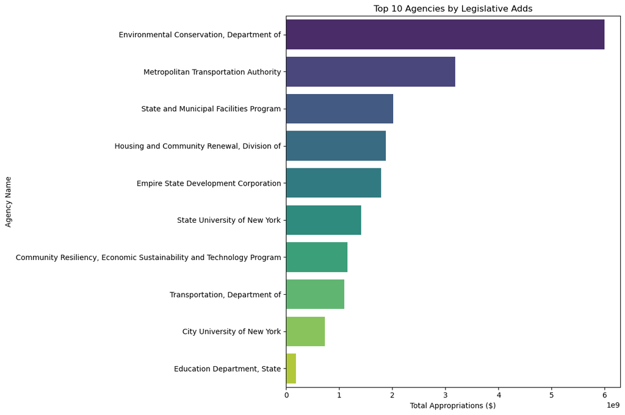

```python
import matplotlib.pyplot as plt
import seaborn as sns

# Get the data sorted by appropriations in descending order
agency_adds = legislative_adds.groupby("agency_name")["appropriations"].sum().sort_values(ascending=False)

# Limit to top N agencies for better visibility:
top_n = 10
agency_adds_top = agency_adds.head(top_n)

# Create a figure with appropriate size
plt.figure(figsize=(12, 8))

# Create a bar plot
sns.barplot(x=agency_adds_top.values,
            y=agency_adds_top.index,
            hue=agency_adds_top.index,  # Set hue to the same as y
            palette='viridis',
            legend=False # Hide the legend since it would be redundant
                )

# Add labels and title
plt.xlabel('Total Appropriations ($)')
plt.ylabel('Agency Name')
plt.title(f'Top {top_n} Agencies by Legislative Adds')

# Adjust layout to ensure everything fits
plt.tight_layout()

# Show the plot
plt.show()
```

To now observe the intentions of the pork concentration:

```python
legislative_adds_purpose = budget_compare[
    budget_compare["_merge"] == "right_only"
]

legislative_adds_purpose.groupby("state_purpose_enacted")["appropriations"].sum().sort_values(ascending=False)
```

```
state_purpose_enacted
Environmental Protection or Improvements                   6.034302e+09
Economic Development                                       3.654900e+09
Mass Transportation and Rail Freight                       3.330250e+09
Program Improvement/Change                                 2.141835e+09
New Facilities                                             1.840500e+09
State and Municipal Facilities Purpose                     1.630000e+09
Preservation of Facilities                                 9.954000e+08
Highway Facilities                                         6.718630e+08
Infrastructure                                             2.100000e+08
Health and Safety                                          9.100000e+07
Transformative Projects                                    1.000000e+07
Aviation                                                   1.000000e+07
Maintenance Facilities                                     6.532000e+06
Community Enhancement                                      0.000000e+00
Facilities for the Physically Disabled                     0.000000e+00
Energy Conservation                                        0.000000e+00
Disaster Assistance                                        0.000000e+00
Western New York Nuclear Service Center Program Purpose    0.000000e+00
World Trade Center                                         0.000000e+00
Name: appropriations, dtype: float64
```

Visual:

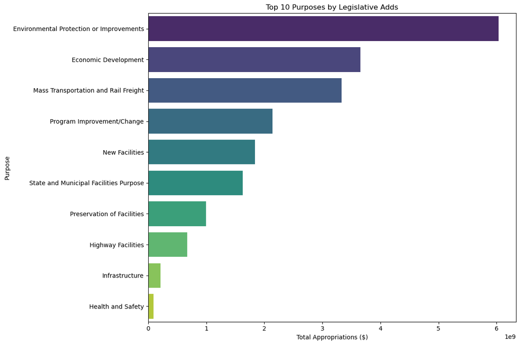

```python
import matplotlib.pyplot as plt
import seaborn as sns

# Get the data sorted by appropriations in descending order
agency_adds_purpose = legislative_adds_purpose.groupby("state_purpose_enacted")["appropriations"].sum().sort_values(ascending=False)

# Limit to top N agencies for better visibility:
top_n = 10
agency_adds_top = agency_adds_purpose.head(top_n)

# Create a figure with appropriate size
plt.figure(figsize=(12, 8))

# Create a bar plot
sns.barplot(x=agency_adds_top.values,
            y=agency_adds_top.index,
            hue=agency_adds_top.index,  # Set hue to the same as y
            palette='viridis',
            legend=False # Hide the legend since it would be redundant
                )

# Add labels and title
plt.xlabel('Total Appropriations ($)')
plt.ylabel('Purpose')
plt.title(f'Top {top_n} Purposes by Legislative Adds')

# Adjust layout to ensure everything fits
plt.tight_layout()

# Show the plot
plt.show()
```

**Budget Change Decomposition -- computing financial changes**

```python
budget_compare["appropriations_exec"] = pd.to_numeric(
    budget_compare["appropriations_recommended"], errors="coerce"
)

budget_compare["appropriations_enacted"] = pd.to_numeric(
    budget_compare["appropriations"], errors="coerce"
)

budget_compare["change"] = (
    budget_compare["appropriations_enacted"] -
    budget_compare["appropriations_exec"]
)

budget_compare["abs_change"] = budget_compare["change"].abs()
```

Classifying budget changes:

```python
conditions = [

    budget_compare["_merge"] == "right_only",
    budget_compare["_merge"] == "left_only",
    budget_compare["change"] > 0,
    budget_compare["change"] < 0
]

choices = [
    "Legislative New Project",
    "Executive Only",
    "Funding Increase",
    "Funding Decrease"
]

budget_compare["budget_change_type"] = np.select(
    conditions,
    choices,
    default="Unchanged"
)
```

Decomposition Table (Executive-Legislative Intervention Matrix):

```python
decomposition = (
    budget_compare
    .groupby(["fiscal_period","budget_change_type"])
    .agg(
        projects=("reference_number","count"),
        total_change=("change","sum")
    )
)

decomposition
```

| fiscal_period | budget_change_type | projects | total_change |
| --- | --- | --- | --- |
| 2015-16 | Executive Only | 1 | 0.000000e+00 |
|  | Funding Decrease | 1 | -4.500000e+07 |
|  | Funding Increase | 9 | 4.750000e+06 |
|  | Legislative New Project | 40 | 0.000000e+00 |
|  | Unchanged | 2124 | 0.000000e+00 |
| 2016-17 | Unchanged | 2316 | 0.000000e+00 |
| 2017-18 | Executive Only | 61 | 0.000000e+00 |
|  | Funding Decrease | 14 | -3.502300e+08 |
|  | Funding Increase | 18 | 8.555300e+08 |
|  | Legislative New Project | 156 | 0.000000e+00 |
|  | Unchanged | 2333 | 0.000000e+00 |
| 2018-19 | Executive Only | 24 | 0.000000e+00 |
|  | Funding Decrease | 11 | -3.149800e+07 |
|  | Funding Increase | 9 | 1.597470e+08 |
|  | Legislative New Project | 119 | 0.000000e+00 |
|  | Unchanged | 2523 | 0.000000e+00 |
| 2019-20 | Executive Only | 6 | 0.000000e+00 |
|  | Funding Decrease | 6 | -3.614500e+07 |
|  | Funding Increase | 5 | 3.665600e+07 |
|  | Legislative New Project | 26 | 0.000000e+00 |
|  | Unchanged | 2674 | 0.000000e+00 |
| 2020-21 | Executive Only | 1 | 0.000000e+00 |
|  | Funding Decrease | 9 | -2.804563e+09 |
|  | Funding Increase | 5 | 4.563000e+06 |
|  | Legislative New Project | 22 | 0.000000e+00 |
|  | Unchanged | 2823 | 0.000000e+00 |
| 2021-22 | Executive Only | 1 | 0.000000e+00 |
|  | Funding Decrease | 15 | -4.650000e+07 |
|  | Funding Increase | 7 | 2.094450e+08 |
|  | Legislative New Project | 30 | 0.000000e+00 |
|  | Unchanged | 2936 | 0.000000e+00 |
| 2023-24 | Executive Only | 23 | 0.000000e+00 |
|  | Funding Increase | 8 | 6.685650e+08 |
|  | Legislative New Project | 76 | 0.000000e+00 |
|  | Unchanged | 3272 | 0.000000e+00 |
| 2024-25 | Executive Only | 9 | 0.000000e+00 |
|  | Funding Decrease | 3 | -4.429700e+07 |
|  | Funding Increase | 10 | 4.627120e+08 |
|  | Legislative New Project | 79 | 0.000000e+00 |
|  | Unchanged | 3458 | 0.000000e+00 |
| 2025-26 | Executive Only | 5 | 0.000000e+00 |
|  | Funding Decrease | 1 | -1.200000e+06 |
|  | Funding Increase | 4 | 1.001250e+08 |
|  | Legislative New Project | 88 | 0.000000e+00 |
|  | Unchanged | 3625 | 0.000000e+00 |

**Legislative Influence Index**

Measures how much the Legislature alters the budget.

Model:

$$Influence_t\,=\,\frac{\sum |Enacted\,-\,Executive|}{Total\,\,Executive}$$

Computation of the index:

```python
influence_index = (
    budget_compare
    .groupby("fiscal_period")
    .agg(
        total_exec=("appropriations_exec","sum"),
        total_abs_change=("abs_change","sum")
    )
)

influence_index["legislative_influence"] = (
    influence_index["total_abs_change"] /
    influence_index["total_exec"]
)

influence_index
```

| fiscal_period | total_exec | total_abs_change | legislative_influence |
| --- | --- | --- | --- |
| 2015-16 | 1.456176e+10 | 4.975000e+07 | 0.003416 |
| 2016-17 | 1.307378e+10 | 0.000000e+00 | 0.000000 |
| 2017-18 | 1.853380e+10 | 1.205760e+09 | 0.065057 |
| 2018-19 | 1.372644e+10 | 1.912450e+08 | 0.013933 |
| 2019-20 | 1.348788e+10 | 7.280100e+07 | 0.005398 |
| 2020-21 | 2.351595e+10 | 2.809126e+09 | 0.119456 |
| 2021-22 | 1.481318e+10 | 2.559450e+08 | 0.017278 |
| 2023-24 | 2.173278e+10 | 6.685650e+08 | 0.030763 |
| 2024-25 | 1.975171e+10 | 5.070090e+08 | 0.025669 |
| 2025-26 | 2.700216e+10 | 1.013250e+08 | 0.003752 |

Case example:

| Value | Interpretation |
| --- | --- |
| 0.00 | Legislature makes no changes |
| 0.05 | 5% of budget altered |
| 0.20 | strong legislative intervention |

**Budget Concentration Shift:**

This indentifies whether legislatures concentrate or redistribute spending.

Computation:

HHI (Herfindahl Index)

Gini coefficient

HHI:

```python
def hhi(values):

    values = values.fillna(0)

    shares = values / values.sum()

    return (shares**2).sum()
```

Executive HHI:

```python
# Explicitly select the columns after groupby
# This approach works with older pandas versions
exec_hhi = (
    budget_compare
    .groupby("fiscal_period")
    # Explicitly select the column we want to work with
    ["appropriations_exec"]
    .apply(lambda x: hhi(x))
)
```

Enacted HHI:

```python
# Explicitly select the columns after groupby
# This approach works with older pandas versions
enacted_hhi = (
    budget_compare
    .groupby("fiscal_period")
    # Explicitly select the column we want to work with
    ["appropriations_enacted"]
    .apply(lambda x: hhi(x))
)
```

Contrast:

```python
hhi_compare = pd.DataFrame({
    "exec_hhi": exec_hhi,
    "enacted_hhi": enacted_hhi
})

hhi_compare["delta_hhi"] = (
    hhi_compare["enacted_hhi"] -
    hhi_compare["exec_hhi"]
)

hhi_compare
```

| fiscal_period | exec_hhi | enacted_hhi | delta_hhi |
| --- | --- | --- | --- |
| 2015-16 | 0.038588 | 0.038588 | 0.0 |
| 2016-17 | 0.040685 | 0.040685 | 0.0 |
| 2017-18 | 0.039139 | 0.039139 | 0.0 |
| 2018-19 | 0.037884 | 0.037884 | 0.0 |
| 2019-20 | 0.039042 | 0.039042 | 0.0 |
| 2020-21 | 0.054497 | 0.054497 | 0.0 |
| 2021-22 | 0.040281 | 0.040281 | 0.0 |
| 2023-24 | 0.035702 | 0.035702 | 0.0 |
| 2024-25 | 0.042120 | 0.042120 | 0.0 |
| 2025-26 | 0.030102 | 0.030102 | 0.0 |

Interpretation:

| ΔHHI | Meaning |
| --- | --- |
| positive | legislature concentrates spending |
| negative | legislature distributes funding |

Gini pipeline:

```python
def gini(x):

    x = np.sort(x)

    n = len(x)

    return (2 * np.arange(1, n+1) - n - 1).dot(x) / (n * x.sum())
```

Computing Gini:

```python
# Corrected code for exec_gini
exec_gini = (
    budget_compare
    .groupby("fiscal_period")
    # Explicitly select the column we want to work with
    ["appropriations_exec"]
    .apply(lambda x: gini(x.fillna(0)))
)

# Corrected code for enacted_gini
enacted_gini = (
    budget_compare
    .groupby("fiscal_period")
    # Explicitly select the column we want to work with
    ["appropriations_enacted"]
    .apply(lambda x: gini(x.fillna(0)))
)
```

Gini compare:

```python
gini_compare = pd.DataFrame({
    "exec_gini": exec_gini,
    "enacted_gini": enacted_gini
})

gini_compare["delta_gini"] = (
    gini_compare["enacted_gini"] -
    gini_compare["exec_gini"]
)

gini_compare
```

| fiscal_period | exec_gini | enacted_gini | delta_gini |
| --- | --- | --- | --- |
| 2015-16 | 0.981584 | 0.979990 | -0.001594 |
| 2016-17 | 0.977404 | 0.977404 | 0.000000 |
| 2017-18 | 0.980817 | 0.978868 | -0.001948 |
| 2018-19 | 0.979337 | 0.977697 | -0.001641 |
| 2019-20 | 0.980006 | 0.978365 | -0.001641 |
| 2020-21 | 0.986309 | 0.984744 | -0.001564 |
| 2021-22 | 0.983801 | 0.981898 | -0.001904 |
| 2023-24 | 0.983402 | 0.980437 | -0.002965 |
| 2024-25 | 0.983330 | 0.978562 | -0.004769 |
| 2025-26 | 0.983635 | 0.979798 | -0.003838 |

Data Insights

```python
gini_compare.info()
```

```
<class 'pandas.core.frame.DataFrame'>
Index: 10 entries, 2015-16 to 2025-26
Data columns (total 3 columns):
 #   Column        Non-Null Count  Dtype
---  ------        --------------  -----
 0   exec_gini     10 non-null     float64
 1   enacted_gini  10 non-null     float64
 2   delta_gini    10 non-null     float64
dtypes: float64(3)
memory usage: 320.0+ bytes
```

Visual:

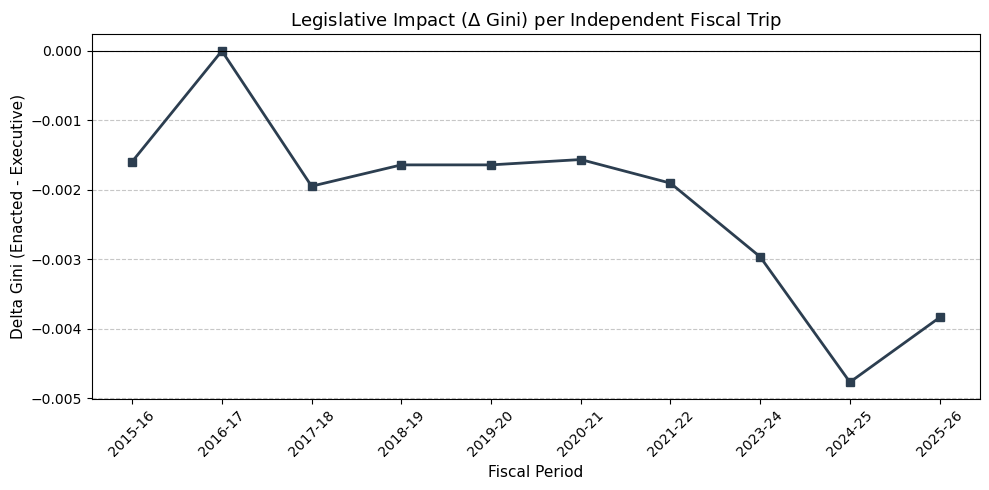

```python
# Data based on the user's provided values
data = {
    'fiscal_period': [
        '2015-16', '2016-17', '2017-18', '2018-19', '2019-20',
        '2020-21', '2021-22', '2023-24', '2024-25', '2025-26'
    ],
    'delta_gini': [
        -0.001594, 0.000000, -0.001948, -0.001641, -0.001641,
        -0.001564, -0.001904, -0.002965, -0.004769, -0.003838
    ]
}

gini_compare = pd.DataFrame(data)

# Create the plot focusing strictly on these two columns
plt.figure(figsize=(10, 5))
plt.plot(gini_compare['fiscal_period'], gini_compare['delta_gini'], marker='s', color='#2c3e50', linewidth=2, label='$\Delta$ Gini')

# Styling
plt.title('Legislative Impact ($\Delta$ Gini) per Independent Fiscal Trip', fontsize=13)
plt.xlabel('Fiscal Period', fontsize=11)
plt.ylabel('Delta Gini (Enacted - Executive)', fontsize=11)
plt.xticks(rotation=45)
plt.grid(True, axis='y', linestyle='--', alpha=0.7)
plt.axhline(0, color='black', linewidth=0.8, linestyle='-') # Baseline for no change
plt.tight_layout()

# Save the plot
plt.savefig('gini_delta_plot.png')

# Save the requested two-column dataframe to CSV
gini_compare.to_csv('gini_compare.csv', index=False)
```

```
  fiscal_period  delta_gini  cumulative_delta
0       2015-16   -0.001594         -0.001594
1       2016-17    0.000000         -0.001594
2       2017-18   -0.001948         -0.003542
3       2018-19   -0.001641         -0.005183
4       2019-20   -0.001641         -0.006824
5       2020-21   -0.001564         -0.008388
6       2021-22   -0.001904         -0.010292
7       2023-24   -0.002965         -0.013257
8       2024-25   -0.004769         -0.018026
9       2025-26   -0.003838         -0.021864
```

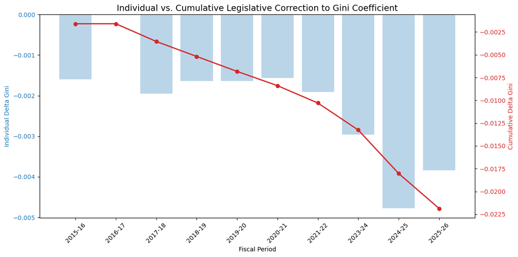

```python
import pandas as pd
import numpy as np
import matplotlib.pyplot as plt

# Loading the data
gini_compare = pd.read_csv('gini_compare.csv')

# Calculating the Cumulative Delta
# Since each trip is independent, this shows the aggregate legislative correction over time
gini_compare['cumulative_delta'] = gini_compare['delta_gini'].cumsum()

# Plotting
fig, ax1 = plt.subplots(figsize=(12, 6))

# Plot 1: The individual Delta for each trip (Bar chart)
color = 'tab:blue'
ax1.set_xlabel('Fiscal Period')
ax1.set_ylabel('Individual Delta Gini', color=color)
ax1.bar(gini_compare['fiscal_period'], gini_compare['delta_gini'], color=color, alpha=0.3, label='Trip Delta')
ax1.tick_params(axis='y', labelcolor=color)

# Plot 2: The Cumulative Delta (Line chart)
ax2 = ax1.twinx()
color = 'tab:red'
ax2.set_ylabel('Cumulative Delta Gini', color=color)
ax2.plot(gini_compare['fiscal_period'], gini_compare['cumulative_delta'], color=color, marker='o', linewidth=2, label='Cumulative Delta')
ax2.tick_params(axis='y', labelcolor=color)

plt.title('Individual vs. Cumulative Legislative Correction to Gini Coefficient', fontsize=14)
# First, tell Matplotlib exactly where the ticks go
ax1.set_xticks(range(len(gini_compare['fiscal_period'])))
# Then, label those specific positions
ax1.set_xticklabels(gini_compare['fiscal_period'], rotation=45)
fig.tight_layout()

plt.savefig('cumulative_gini_plot.png')
print(gini_compare[['fiscal_period', 'delta_gini', 'cumulative_delta']])
```

The cumulative view shows the total distance the legislature has moved the Gini coefficient away from the executive's original proposals over the last decade.

**Cumulative Impact Analysis:**

By the end of the 2025-26 period, the legislature has effectively "corrected" the executive's Gini projections by a total of -0.021864.

To put that in perspective:

2015–2021: The cumulative change was relatively slow and linear.

2023–2026: In just the last three appropritaions, the legislature has added -0.011572 to the cumulative delta—meaning more than 50% of the total 11-year correction occurred in the final three cycles.

**Legislative Pork-Barrel Detection (NLP):**

Extract legislative projects--

```python
legislative_adds = budget_compare[
    budget_compare["_merge"] == "right_only"
]
```

Text Analysis of Project Descriptions. Applying the 'description_enacted' attribute:

```python
from sklearn.feature_extraction.text import CountVectorizer

vectorizer = CountVectorizer(
    stop_words="english",
    max_features=50
)

X = vectorizer.fit_transform(
    legislative_adds["description_enacted"]
)

keywords = pd.DataFrame(
    X.toarray(),
    columns=vectorizer.get_feature_names_out()
)

keywords.sum().sort_values(ascending=False)
```

```
facilities       38
capital          34
program          34
health           29
state            27
nymtc            24
maintenance      22
preservation     22
safety           21
development      19
ps               17
add              17
community        17
services         16
housing          14
rehab            14
municipal        14
engineering      13
park             13
non              13
water            13
improvement      12
bonded           12
environmental    12
fy26             11
additional       11
economic         11
protection       11
conservation     11
shift            10
climate          10
federal          10
ny               10
gifts            10
miscellaneous    10
nys               9
metro             9
trans             9
strategic         9
land              9
source            9
energy            9
fair              9
council           9
public            9
museum            9
construction      9
lake              9
library           8
point             8
dtype: int64
```

Top 13 case:

[output not shown]

Secor dictionary:

```python
sector_map = {
    "infrastructure": [
        "facilities","capital","maintenance","preservation",
        "engineering","construction","improvement","bonded"
    ],

    "housing_urban": [
        "housing","rehab","municipal","development","community"
    ],

    "environment": [
        "environmental","conservation","climate","water",
        "park","lake","land","energy"
    ],

    "transportation": [
        "metro","trans","nymtc"
    ],

    "public_safety": [
        "safety","protection","ps"
    ],

    "health_services": [
        "health","services","public"
    ],

    "economic_development": [
        "economic","strategic","fair"
    ],

    "cultural_civic": [
        "museum","library","council"
    ],

    "government_admin": [
        "state","federal","ny","nys","source","program"
    ],

    "budget_misc": [
        "additional","add","shift","miscellaneous",
        "gifts","non","fy26","point"
    ]
}
```

Automatic Classification Function:

```python
def classify_sector(text):

    text = str(text).lower()

    for sector, words in sector_map.items():
        if any(w in text for w in words):
            return sector

    return "other"
```

Incorporating into dataset:

```python
budget_compare["sector"] = budget_compare["description_enacted"].apply(classify_sector)
budget_compare.info()
```

```
<class 'pandas.core.frame.DataFrame'>
RangeIndex: 28986 entries, 0 to 28985
Data columns (total 32 columns):
 #   Column                        Non-Null Count  Dtype
---  ------                        --------------  -----
 0   agency_name                   28986 non-null  object
 1   reference_number              28986 non-null  object
 2   program_name_exec             28350 non-null  object
 3   state_purpose_exec            28350 non-null  object
 4   fund_name_exec                28350 non-null  object
 5   financing_source_exec         28350 non-null  object
 6   chapter_section_year_exec     28350 non-null  object
 7   description_exec              28350 non-null  object
 8   reappropriations_recommended  28350 non-null  float64
 9   encumbrances_exec             28350 non-null  float64
```

[output cut: 24 more lines]

Sector budget analysis:

```python
sector_spending = (
    budget_compare
    .groupby("sector")["appropriations"]
    .sum()
    .sort_values(ascending=False)
)

sector_spending
```

```
sector
other                   6.306070e+10
infrastructure          5.469902e+10
government_admin        2.887919e+10
public_safety           1.300596e+10
environment             1.278126e+10
transportation          8.349859e+09
housing_urban           7.900603e+09
economic_development    1.901500e+09
budget_misc             1.884622e+09
cultural_civic          1.609000e+09
health_services         3.512090e+08
Name: appropriations, dtype: float64
```

Agency Legislative Gain. Which agencies benefit most.

```python
agency_gain = (
    legislative_adds
    .groupby("agency_name")
    .agg(
        total_projects=("reference_number","count"),
        total_spending=("appropriations_enacted","sum")
    )
)

agency_gain.sort_values("total_spending", ascending=False)
```

| agency_name | total_projects | total_spending |
| --- | --- | --- |
| Environmental Conservation, Department of | 153 | 5.994302e+09 |
| Metropolitan Transportation Authority | 4 | 3.185000e+09 |
| State and Municipal Facilities Program | 6 | 2.015000e+09 |
| Housing and Community Renewal, Division of | 35 | 1.879600e+09 |
| Empire State Development Corporation | 36 | 1.792900e+09 |
| State University of New York | 20 | 1.410000e+09 |
| Community Resiliency, Economic Sustainability and Technology Program | 3 | 1.155000e+09 |
| Transportation, Department of | 72 | 1.097613e+09 |
| City University of New York | 10 | 7.300000e+08 |
| Education Department, State | 25 | 1.870000e+08 |
| Motor Vehicles, Department of | 2 | 1.784600e+08 |
| Higher Education Facilities Capital Matching Grants Program | 3 | 1.100000e+08 |
| Health, Department of | 11 | 1.025320e+08 |
| Local Community Assistance Program | 1 | 1.000000e+08 |
| Lake Ontario Resiliency/Economic Development | 1 | 1.000000e+08 |
| Parks, Recreation and Historic Preservation, Office of | 56 | 8.000000e+07 |
| Criminal Justice Services, Division of | 2 | 7.500000e+07 |
| Agriculture and Markets, Department of | 26 | 6.450000e+07 |
| Arts and Cultural Facilities Improvement | 4 | 6.000000e+07 |
| Elections, State Board of | 3 | 5.470000e+07 |
| Public Facilities Sustainability Program | 1 | 5.000000e+07 |
| Special Infrastructure Account | 3 | 4.500000e+07 |
| Military and Naval Affairs, Division of | 9 | 2.800000e+07 |
| Olympic Regional Development Authority | 1 | 2.800000e+07 |
| Homeland Security and Emergency Services, Division of | 1 | 2.500000e+07 |
| Alcoholism and Substance Abuse Services, Office of | 2 | 2.000000e+07 |
| Mental Health, Office of | 7 | 2.000000e+07 |
| Nonprofit Infrastructure Capital Investment Program | 1 | 2.000000e+07 |
| General Services, Office of | 14 | 7.000000e+06 |
| Victim Services, Office of | 1 | 4.300000e+06 |
| Veterans’ Services, Department of | 5 | 4.000000e+06 |
| State, Department of | 1 | 2.000000e+06 |
| Judiciary | 1 | 1.675000e+06 |
| Temporary and Disability Assistance, Office of | 1 | 0.000000e+00 |
| Corrections and Community Supervision, Department of | 34 | 0.000000e+00 |
| Strategic Investment Program | 3 | 0.000000e+00 |
| Community Enhancement Facilities Assistance | 1 | 0.000000e+00 |
| High Technology and Development Program | 3 | 0.000000e+00 |
| State Police, Division of | 14 | 0.000000e+00 |
| Special Infrastructure Account, New York State | 20 | 0.000000e+00 |
| Regional Economic Development Program | 3 | 0.000000e+00 |
| People with Developmental Disabilities, Office for | 21 | 0.000000e+00 |
| Economic Development Capital | 4 | 0.000000e+00 |
| Economic Development Program, New York State | 6 | 0.000000e+00 |
| Energy Research and Development Authority, New York State | 4 | 0.000000e+00 |
| World Trade Center - Department of Transportation | 2 | 0.000000e+00 |

Visual for legislative influence index:

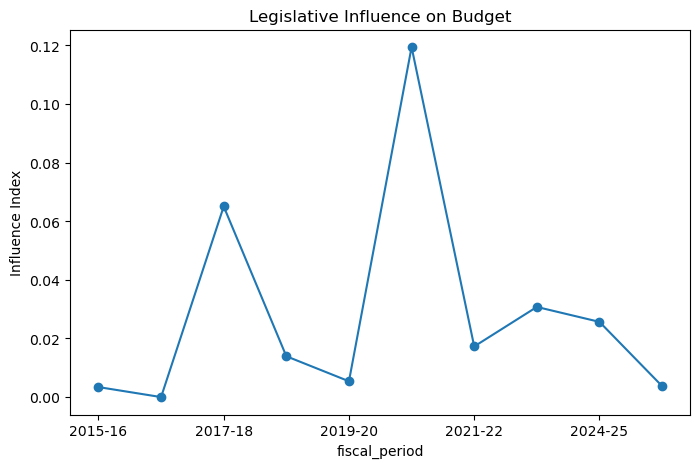

```python
import matplotlib.pyplot as plt

influence_index["legislative_influence"].plot(
    kind="line",
    marker="o",
    figsize=(8,5)
)

plt.title("Legislative Influence on Budget")
plt.ylabel("Influence Index")

plt.show()
```

## Closing Remarks

This project successfully constructed a comprehensive analytical pipeline for New York State capital budget data, integrating both the Executive Budget proposals and the Enacted Budget outcomes across multiple fiscal periods. Through systematic data acquisition, normalisation, validation, and analytical transformation, the work produced a consistent longitudinal dataset suitable for policy and fiscal research.

## References

Bellù, L. G. and Liberati, P. (2006). Describing Income Inequality : Theil Index and Entropy Class Indexes. EASYPol: Resources for Policy Making. *Food and Agriculture Organisation of the United Nations*

Catalog. State of New York. (n.d.). https://data.ny.gov/browse?q=New+York+State+Enacted+Budget+Capital+Appropriations&sortBy=relevance&pageSize=20

Catalog. State of New York. (n.d.). https://data.ny.gov/browse?q=New%2BYork%2BState%2BExecutive%2BBudget%2BCapital%2BAppropriations&sortBy=relevance&pageSize=20&page=1

Karam, S. and Ryerson, M. S. (September 2023). Operating at the Individual Level: A Review of Literature and a Research Agenda to Support Needs-Forward Models of Transport Resource Allocation. *Transportation Research Interdisciplinary Perspectives*, Volume 21, 100887. https://doi.org/10.1016/j.trip.2023.100887

Kenton, W.(2025). Understanding Pork Barrel Politics: Definitions and Reform. *Investopedia* https://www.investopedia.com/terms/p/pork_barrel_politics.asp

Lienert, I. (2010). Role of the Legislature in Budget Processes. Technical Notes and Manuals, 2010(004), Article A001, A001. Retrieved Mar 6, 2026, from https://doi.org/10.5089/9781462398973.005.A001